# Temperature graph with inset of relevant region

We also specify the projection, the coast lines, and ask for the global area to be displayed. The latter prevents the figure form just showing the selection of interest, i.e., the small strip along the equator.

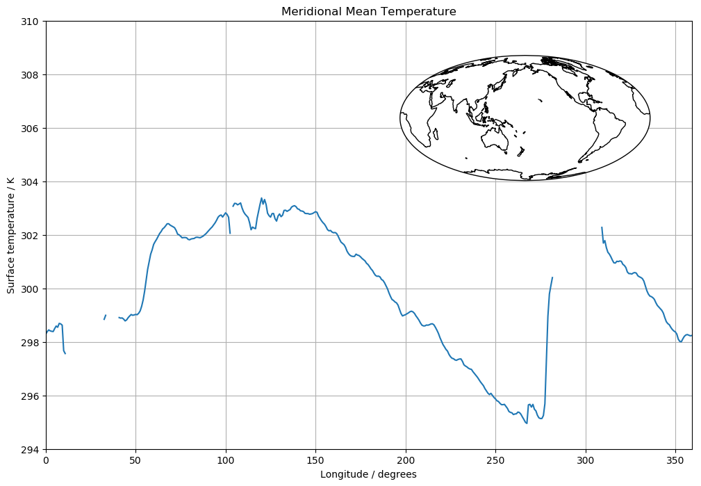

```python
import cartopy.crs as ccrs
import iris.plot as iplt

ax_sub = fig.add_axes([0.55, 0.58, 0.3, 0.25],
                      projection=ccrs.Mollweide(central_longitude=180))
ax_sub.set_global()
ax_sub.coastlines()

fig
```

Use iris.plot (iplt) here so colour bar properties can be specified. Also use a sequential colour scheme to reduce confusion for those with colour-blindness

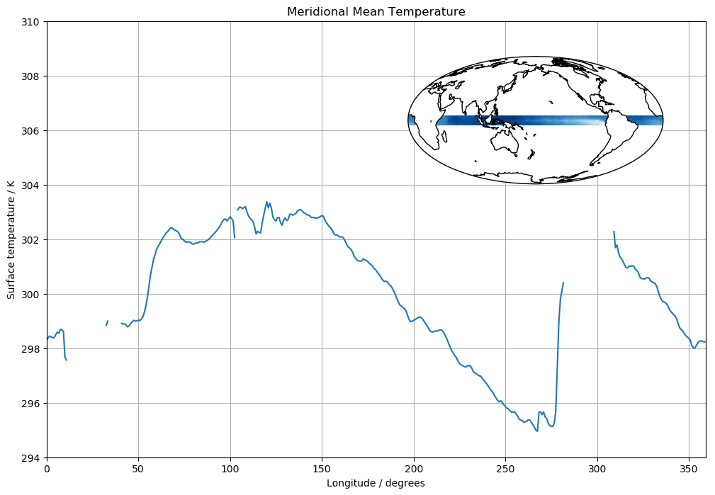

```python
import iris.plot as iplt

image = iplt.pcolormesh(region, cmap='Blues', axes=ax_sub)
fig
```

Manually set the orientation and tick marks on your colour bar. We specify the `image` variable as input to the colour bar: this is the color mesh we created before.

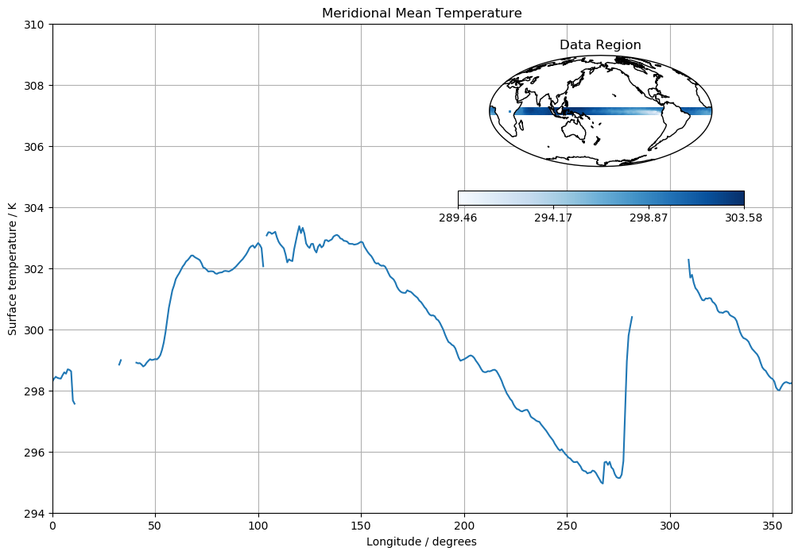

```python
import numpy as np

ticklist = np.linspace(np.min(region.data), np.max(region.data), 4)
fig.colorbar(image, orientation='horizontal', ticks=ticklist)
ax_sub.set_title('Data Region')
fig
```